# Classification and Regression Tree (CART)

April, 2019

In this lab we will go through the model building, validation, and interpretation of tree models. The focus will be on `rpart` package. Recall that when the response variable $Y$ is continuous, we fit regression tree; when the reponse variable $Y$ is categorical, we fit classification tree. We build tree models for our familiar datasets, Boston Housing data and Credit Card Default data, for regression and classification tree respectively.

## Regression Tree (Boston Housing Data)

### Preparation

Load the data, and randomly split to training and testing sample.

```r
library(tidyverse)
library(MASS)
data(Boston)
index <- sample(nrow(Boston),nrow(Boston)*0.90)
boston.train <- Boston[index,]
boston.test <- Boston[-index,]
```

We will use the ‘rpart’ library for model building and ‘rpart.plot’ for plotting.

```r
install.packages('rpart')
install.packages('rpart.plot')
```

```r
library(rpart)
library(rpart.plot)
```

### Fitting regression tree

The simple form of the *rpart* function is similar to *lm* and *glm*. It takes a formula argument in which you specify the response and predictor variables, and a data argument in which you specify the data frame.

```r
boston.rpart <- rpart(formula = medv ~ ., data = boston.train)
```

#### Printing and ploting the tree

```r
boston.rpart
```

```
## n= 455
##
## node), split, n, deviance, yval
##       * denotes terminal node
##
##  1) root 455 38536.4300 22.62022
##    2) rm< 6.797 370 13542.1300 19.59865
##      4) lstat>=14.4 155  2908.5710 14.93097
##        8) crim>=6.99237 63   761.1032 11.77937 *
##        9) crim< 6.99237 92  1093.2090 17.08913 *
##      5) lstat< 14.4 215  4821.9370 22.96372
##       10) lstat>=4.52 207  3001.1550 22.50483
##         20) lstat>=9.715 100   635.1251 20.74300 *
##         21) lstat< 9.715 107  1765.5270 24.15140 *
##       11) lstat< 4.52 8   649.2987 34.83750 *
##    3) rm>=6.797 85  6911.7480 35.77294
##      6) rm< 7.437 57  2291.8200 31.24386
##       12) lstat>=11.315 8   420.9288 20.91250 *
##       13) lstat< 11.315 49   877.5841 32.93061 *
##      7) rm>=7.437 28  1070.5190 44.99286 *
```

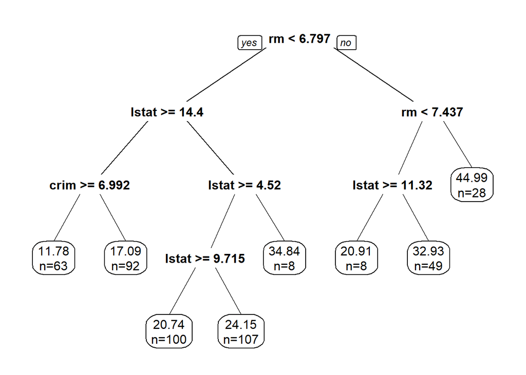

```r
prp(boston.rpart, digits = 4, extra = 1)
```

Make sure you know how to interpret this tree model!

**Exercise:** What is the predicted median housing price (in thousand) given following information:

| crim | zn | indus | chas | nox | rm | age | dis | rad | tax | ptratio | black | lstat |
| --- | --- | --- | --- | --- | --- | --- | --- | --- | --- | --- | --- | --- |
| 0.05 | 0 | 3.41 | 0 | 0.49 | 7.08 | 63.1 | 3.41 | 2 | 270 | 17.8 | 396.06 | 5.7 |

### Prediction using regression tree

The in-sample and out-of-sample prediction for regression tree is also similar to `lm()` and `glm()` models.

In-sample prediction

```r
boston.train.pred.tree = predict(boston.rpart)
```

Out-of-sample prediction

```r
boston.test.pred.tree = predict(boston.rpart, newdata=boston.test)
```

**Exercise:** Calculate the mean squared error (MSE) and mean squared prediction error (MSPE) for this tree model

```r
MSE.tree<-
MSPE.tree<-
```

### Comparing the performance of regression tree with linear regression model in terms of prediction error (Exercise)

Calculate the mean squared error (MSE) and mean squared prediction error (MSPE) for linear regression model using all variables. Then compare the results. What is your conclusion? Further, try to compare the regression tree with the best linear regression model using some variable selection procedures.

```r
boston.lm<-
boston.train.pred.lm<-
boston.test.pred.lm<-
MSE.lm<-
MSPE.lm<-
```

Back to top

## Classification Tree (Credit Card Default data)

### Preparation

Load the data, rename response variable (because it is too long), convert categorical variable to factor, and randomly split to training and testing sample.

```r
credit.data <- read.csv("http://homepages.uc.edu/~lis6/DataMining/Data/credit_default.csv", header=T)
# rename
library(dplyr)
credit.data<- rename(credit.data, default=default.payment.next.month)

# convert categorical data to factor
credit.data$SEX<- as.factor(credit.data$SEX)
credit.data$EDUCATION<- as.factor(credit.data$EDUCATION)
credit.data$MARRIAGE<- as.factor(credit.data$MARRIAGE)

# random splitting
index <- sample(nrow(credit.data),nrow(credit.data)*0.80)
credit.train = credit.data[index,]
credit.test = credit.data[-index,]
```

### Fitting classification tree

You need to tell R you want a classification tree. We have to specify `method="class"`, since the default is to fit regression tree.

```r
credit.rpart0 <- rpart(formula = default ~ ., data = credit.train, method = "class")
```

However, this tree minimizes the symmetric cost, which is misclassification rate. We can take a look at the confusion matrix.

```r
pred0<- predict(credit.rpart0, type="class")
table(credit.train$default, pred0, dnn = c("True", "Pred"))
```

```
##     Pred
## True    0    1
##    0 7209  308
##    1 1369  714
```

Note that in the `predict()` function, we need `type="class"` in order to get binary prediction.

Look at the confusion matrix, is it what we expected? Think about why the confusion matrix is like this?

Therefore, for most applications (very unbalanced data), we often have asymmetric cost. Recall the example in logistic regression. In the credit scoring case it means that false negatives (predicting 0 when truth is 1, or giving out loans that end up in default) will cost more than false positives (predicting 1 when truth is 0, rejecting loans that you should not reject).

Here we make the assumption that false negative cost 5 times of false positive. In real life the cost structure should be carefully researched.

```r
credit.rpart <- rpart(formula = default ~ . , data = credit.train, method = "class", parms = list(loss=matrix(c(0,5,1,0), nrow = 2)))
```

- The parms argument, which is a list. The most import element is the loss matrix. The diagonal elements are 0, and off-diagonal elements tells you the loss(cost) of classifying something wrong. For binary classification, the numbers in c() specify the cost in this sequence: c(0, False Negative, False Positive, 0). If you have symmetric cost, you can ignore the parms argument.

For more advanced controls, you should carefully read the help document for the rpart function.

#### Printing and ploting the tree

```r
credit.rpart
```

```
## n= 9600
##
## node), split, n, loss, yval, (yprob)
##       * denotes terminal node
##
##  1) root 9600 7517 1 (0.78302083 0.21697917)
##    2) PAY_0< 0.5 7468 4890 0 (0.86904124 0.13095876)
##      4) PAY_AMT2>=1640.5 4724 2415 0 (0.89775614 0.10224386)
##        8) PAY_4< 1 4484 2105 0 (0.90611062 0.09388938) *
##        9) PAY_4>=1 240  178 1 (0.74166667 0.25833333) *
##      5) PAY_AMT2< 1640.5 2744 2249 1 (0.81960641 0.18039359)
##       10) LIMIT_BAL>=65000 1745 1330 0 (0.84756447 0.15243553)
##         20) BILL_AMT1>=8583 617  300 0 (0.90275527 0.09724473) *
##         21) BILL_AMT1< 8583 1128  922 1 (0.81737589 0.18262411)
##           42) PAY_AMT4>=962 349  190 0 (0.89111748 0.10888252) *
##           43) PAY_AMT4< 962 779  611 1 (0.78433890 0.21566110) *
##       11) LIMIT_BAL< 65000 999  770 1 (0.77077077 0.22922923) *
##    3) PAY_0>=0.5 2132 1027 1 (0.48170732 0.51829268) *
```

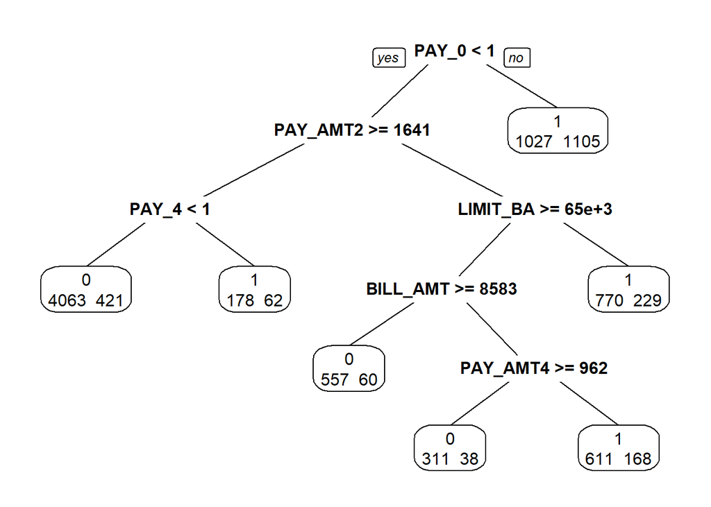

```r
prp(credit.rpart, extra = 1)
```

### Prediction using classification tree

For a binary classification problem, there are 2 types of predictions. One is the predicted class of response (0 or 1), and the second type is the probability of response being 1. We use an additional argument type=“class” or type=“prob” to get these:

In-sample prediction

```r
credit.train.pred.tree1<- predict(credit.rpart, credit.train, type="class")
table(credit.train$default, credit.train.pred.tree1, dnn=c("Truth","Predicted"))
```

```
##      Predicted
## Truth    0    1
##     0 4931 2586
##     1  519 1564
```

**Exercise:** Out-of-sample prediction

```r
#Predicted Class
credit.test.pred.tree1<-
table()
```

**Exercise:** Try `type="prob"` in prediction, what can you say about these predicted probabilities?

### Calculate the actual cost using a self-defined cost function.

We can get the expected loss for this tree model by defining a cost function that has the correct weights:

```r
cost <- function(r, pi){
  weight1 = 5
  weight0 = 1
  c1 = (r==1)&(pi==0) #logical vector - true if actual 1 but predict 0
  c0 = (r==0)&(pi==1) #logical vector - true if actual 0 but predict 1
  return(mean(weight1*c1+weight0*c0))
}
```

Calculate the cost for training sample using above cost function

```r
cost(credit.train$default,credit.train.pred.tree1)
```

```
## [1] 0.5396875
```

**Exercise:** Calculate the cost for testing sample.

### Comparing this classification tree with logistic regression

We can compare this model’s out-of-sample performance with the logistic regression model with all variables in it. Recall that when we search for the optimal cut-off using the same cost function we get optimal cut-off at about 0.21.

```r
#Fit logistic regression model
credit.glm<- glm(default~., data = credit.train, family=binomial)
#Get binary prediction
credit.test.pred.glm<- as.numeric(predict(credit.glm, credit.test, type="response")>0.21)
#Calculate cost using test set
cost(credit.test$default,credit.test.pred.glm)
```

```
## [1] 0.6854167
```

```r
#Confusion matrix
table(credit.test$default, credit.test.pred.glm, dnn=c("Truth","Predicted"))
```

```
##      Predicted
## Truth    0    1
##     0 1256  595
##     1  210  339
```

**Exercise:** Comparison for in-sample performance.

Which model do you think is better?

### ROC Curve for Classification Tree

To get ROC curve, we get the predicted probability of Y being 1 from the fitted tree.

```r
credit.test.prob.rpart<- predict(credit.rpart,credit.test, type="prob")
```

credit.test.prob.rpart has 2 columns, the first one is prob(Y) = 0 and the second prob(Y) = 1. **We need the second column**.

To get ROC curve we use

```r
library(ROCR)
```

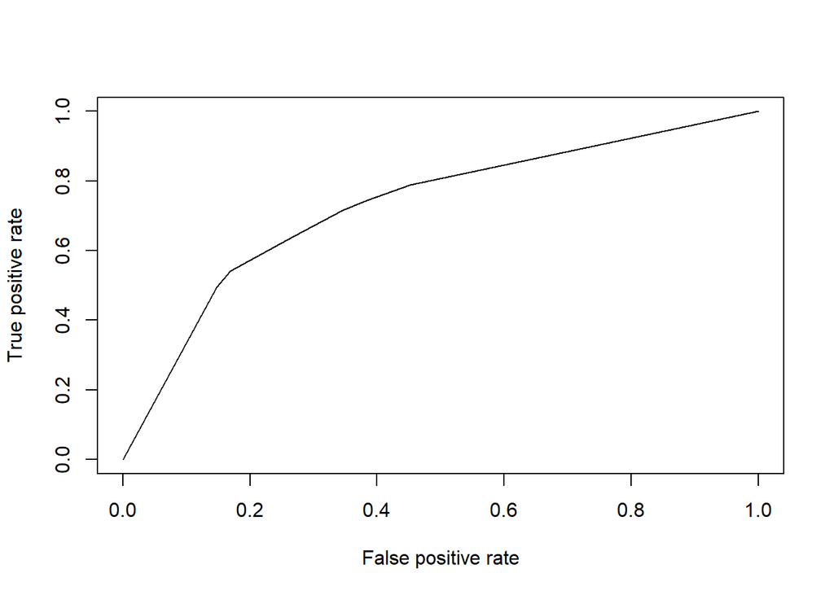

```r
pred = prediction(credit.test.prob.rpart[,2], credit.test$default)
perf = performance(pred, "tpr", "fpr")
plot(perf)
```

Area under the curve is given by (do not worry about the syntax here):

```r
slot(performance(pred, "auc"), "y.values")[[1]]
```

```
## [1] 0.7290762
```

**Exercise:** Draw the ROC curve for training sample.

## Pruning

In rpart(), the cp(complexity parameter) argument is one of the parameters that are used to control the compexity of the tree. The help document for rpart tells you “Any split that does not decrease the overall lack of fit by a factor of cp is not attempted”. For a regression tree, the overall Rsquare must increase by cp at each step. Basically, the smaller the cp value, the larger (complex) tree rpart will attempt to fit. The default value for cp is 0.01.

```r
boston.largetree <- rpart(formula = medv ~ ., data = boston.train, cp = 0.001)
```

Try plot it yourself to see its structure.

```r
prp(boston.largetree)
```

The plotcp() function gives the relationship between 10-fold cross-validation error in the training set and size of tree.

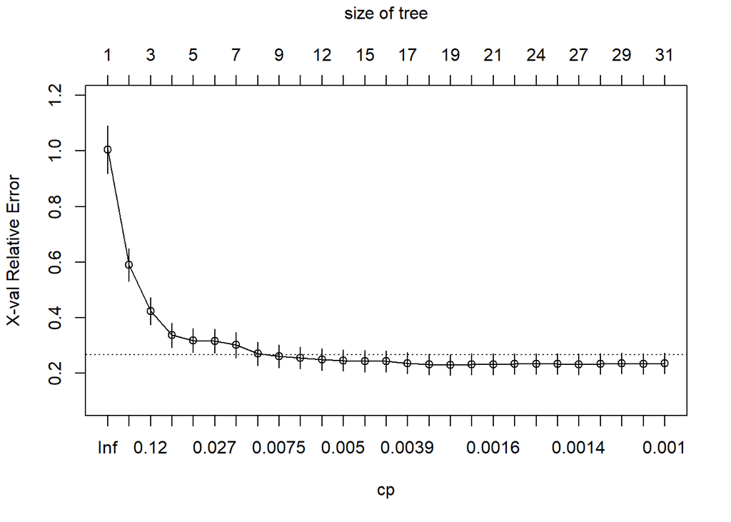

```r
plotcp(boston.largetree)
```

You can observe from the above graph that the cross-validation error (x-val) does not always go down when the tree becomes more complex. The analogy is when you add more variables in a regression model, its ability to predict future observations not necessarily increases. A good choice of cp for pruning is often the leftmost value for which the mean lies below the horizontal line. In the Boston housing example, you may conclude that having a tree mode with more than 10 splits is not helptul.

To look at the error vs size of tree more carefully, you can look at the following table:

```r
printcp(boston.largetree)
```

```
##
## Regression tree:
## rpart(formula = medv ~ ., data = boston.train, cp = 0.001)
##
## Variables actually used in tree construction:
##  [1] age     black   crim    dis     indus   lstat   nox     ptratio
##  [9] rm      tax
##
## Root node error: 38536/455 = 84.695
##
## n= 455
##
##           CP nsplit rel error  xerror     xstd
## 1  0.4692327      0   1.00000 1.00519 0.086612
## 2  0.1508085      1   0.53077 0.59011 0.058555
```

[output cut: 25 more lines]

Root node error is the error when you do not do anything too smart in prediction, in regression case, it is the mean squared error(MSE) if you use the average of medv as the prediction. Note it is the same as

```r
sum((boston.train$medv - mean(boston.train$medv))^2)/nrow(boston.train)
```

```
## [1] 84.69546
```

The first 2 columns CP and nsplit tells you how large the tree is. rel.error $\times$ root node error gives you the in sample error. For example, the last row “(rel error)*(root node error)“, which is the same as the in-sample MSE if you calculate using predict:

```r
mean((predict(boston.largetree) - boston.train$medv)^2)
```

```
## [1] 9.627137
```

xerror gives you the cross-validation (default is 10-fold) error. You can see that the rel error (in-sample error) is always decreasing as model is more complex, while the cross-validation error (measure of performance on future observations) is not. That is why we **prune** the tree to avoid overfitting the training data.

```r
tree.prune<- prune(boston.largetree, cp = 0.008)
tree.prune$cptable
```

```
##            CP nsplit rel error    xerror       xstd
## 1 0.469232750      0 1.0000000 1.0051894 0.08661198
## 2 0.150808478      1 0.5307673 0.5901101 0.05855456
## 3 0.092105275      2 0.3799588 0.4234953 0.04950210
## 4 0.030399365      3 0.2878535 0.3362820 0.04475830
## 5 0.027357463      4 0.2574541 0.3181666 0.04305025
## 6 0.025775803      5 0.2300967 0.3155939 0.04308958
## 7 0.015582728      6 0.2043209 0.3012764 0.04538707
## 8 0.009033196      7 0.1887381 0.2698540 0.04252968
## 9 0.008000000      8 0.1797049 0.2607654 0.04069443
```

**Exercise:** Prune a classification tree. Start with “cp=0.001”, and find a reasonable cp value, then obtain the pruned tree.

Back to top

## CART for MNIST data

### Preparations

#### Load data

```r
digit<- data.matrix(read_csv("https://www.dropbox.com/s/ulujvi2a4ykfzju/train.csv?dl=1"))
dim(digit)
```

```
## [1] 42000   785
```

#### Visualizing data

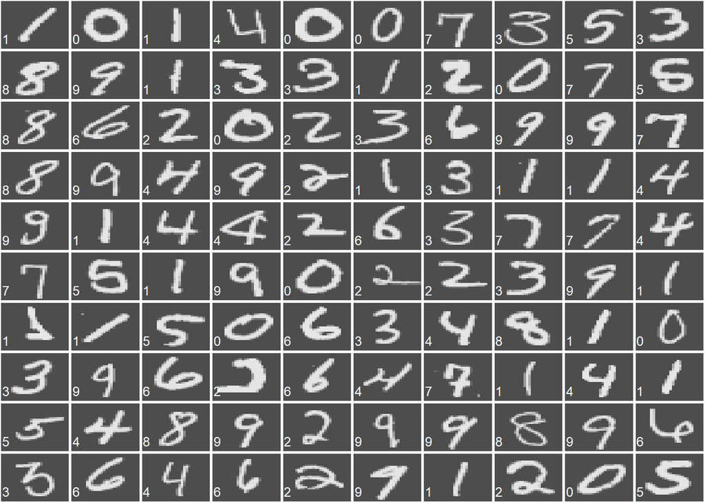

```r
## visualize the data
plotTrain <- function(data, index){
  op <- par(no.readonly=TRUE)
  x <- ceiling(sqrt(length(index)))
  par(mfrow=c(x, x), mar=c(.1, .1, .1, .1))

  for (i in index){ #reverse and transpose each matrix to rotate images
    m <- matrix(data[i,-1], nrow=28, byrow=TRUE)
    m <- apply(m, 2, rev)
    image(t(m), col=grey.colors(255), axes=FALSE)
    text(0.05, 0.2, col="white", cex=1.2, data[i, 1])
  }
  par(op) #reset the original graphics parameters
}

plotTrain(data=digit, index=1:100)
```

#### Split data to training and testing

```r
index<- sample(1:nrow(digit), 0.6*nrow(digit))
train<- digit[index,]
test<- digit[-index,]
```

#### Standardize

Currently, each cell uses 0-255 to represent the grey color scale. We recale it to 0-1.

```r
## standardize X
train.x <- train[,-1] #remove 'label' column
test.x<- test[,-1]
train.y <- train[,1] #label column
test.y<- test[,1]
train.x <- train.x/255
test.x <- test.x/255
```

#### Classification tree

Here we use classification tree to train a classifier, and then compare with the multinomial logit model (in last lab).

Due to the large size, we only use first 3000 observations as training sample.

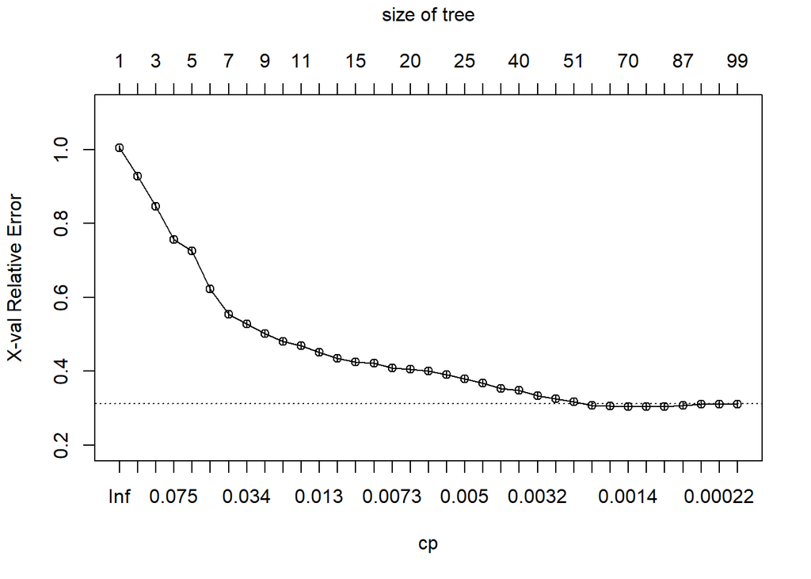

```r
fit.tree <- rpart(y ~., method = "class", data = data.frame(y=train.y[1:3000], x=train.x[1:3000,]), cp=0.00001)
plotcp(fit.tree)
```

```r
printcp(fit.tree)
```

```
##
## Classification tree:
## rpart(formula = y ~ ., data = data.frame(y = train.y[1:3000],
##     x = train.x[1:3000, ]), method = "class", cp = 1e-05)
##
## Variables actually used in tree construction:
##  [1] x.pixel122 x.pixel126 x.pixel128 x.pixel153 x.pixel154 x.pixel155
##  [7] x.pixel158 x.pixel177 x.pixel210 x.pixel211 x.pixel213 x.pixel235
## [13] x.pixel240 x.pixel241 x.pixel263 x.pixel265 x.pixel267 x.pixel269
## [19] x.pixel270 x.pixel271 x.pixel272 x.pixel290 x.pixel297 x.pixel301
## [25] x.pixel315 x.pixel317 x.pixel318 x.pixel324 x.pixel326 x.pixel344
## [31] x.pixel345 x.pixel346 x.pixel347 x.pixel350 x.pixel351 x.pixel352
## [37] x.pixel353 x.pixel354 x.pixel355 x.pixel358 x.pixel372 x.pixel374
## [43] x.pixel375 x.pixel378 x.pixel380 x.pixel382 x.pixel386 x.pixel404
## [49] x.pixel405 x.pixel426 x.pixel430 x.pixel437 x.pixel439 x.pixel455
```

[output cut: 47 more lines]

```r
# make prediction
pred.y.tree<- predict(fit.tree, data.frame(y=test.y, x=test.x), type = "class")
# accuracy rate
mean(test.y==pred.y.tree)
```

```
## [1] 0.7339286
```

We got pretty good accuracy. As we learn more advanced ML algorithm, you will see that the accuracy rate could hit to 99%.

#### Visualize the results

```r
plotResults <- function(testdata, index, preds){
  op <- par(no.readonly=TRUE)
  x <- ceiling(sqrt(length(index)))
  par(mfrow=c(x,x), mar=c(.1,.1,.1,.1))

  for (i in index){
    m <- matrix(testdata[i,], nrow=28, byrow=TRUE)
    m <- apply(m, 2, rev)
    image(t(m), col=grey.colors(255), axes=FALSE)
    text(0.05,0.1,col="green", cex=1.2, preds[i])
  }
  par(op)
}
```

Here are the first 100 images in the test set and their predicted values:

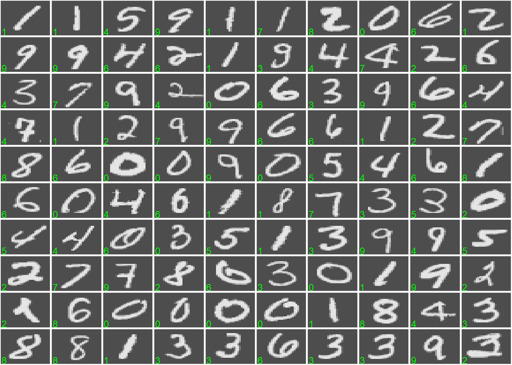

```r
plotResults(testdata=test.x, index=1:100, preds=pred.y.tree)
```

## Things to remember

- Use `rpart()` to fit regression and classification tree.
- Know how to interpret a tree.
- Use `predict()` for prediction, and how to assess the performance.
- Know how to use Cp plot/table to prune a large tree.